# Mckay

Julie Overgaard

2024-04-22

## Setting up the right packages:

## Getting the Mckay pdf text:

```r
mckay <- pdf_text('datamckay/Merry Wiesner-Hanks & Patricia Buckley Ebrey & Roger Beck & Jerry Davila & Clare Crowston & John P. McKay - A History of World Societies, Combined-Bedford Books (2017).pdf')
mckay_df <- data.frame(text = mckay) %>%
  mutate(page = 1:n())

mckay_text <- mckay_df %>%
  filter(page %in% 1:20) %>%
  mutate(text = str_split(text, '\n')) %>%
  unnest(text)
```

## Focus on chapter 14

-Setting it up so mckay_ch14 contains mckays chapter 14 about the Middle ages

```r
mckay_ch14 <- mckay[845:906]
```

### Some wrangling:

- Split up pages into separate lines (separated by `\n`) using `stringr::str_split()`
- Unnest into regular columns using `tidyr::unnest()`
- Remove leading/trailing white space with `stringr::str_trim()`

```r
mckay_df <- data.frame(mckay_ch14) %>%
  mutate(text_full1 = str_split(mckay_ch14, pattern = '\n')) %>%
  unnest(text_full1) %>%
  mutate(text_full1 = str_trim(text_full1))
view(mckay_df)
```

Now each line, on each page, is its own row, with extra starting & trailing spaces removed.

### Get the tokens (individual words) in tidy format

Use `tidytext::unnest_tokens()` (which pulls from the `tokenizer`) package, to split columns into tokens. We are interested in *words*, so that’s the token we’ll use:

```r
mckay_tokens <- mckay_df %>%
  unnest_tokens(word, text_full1)
```

## Counting the words

```r
mckay_wc <- mckay_tokens %>%
  count(word) %>%
  arrange(-n)
mckay_wc
```

```
## # A tibble: 3,884 × 2
##    word      n
##    <chr> <int>
##  1 the    1274
##  2 and     822
##  3 of      712
##  4 in      508
##  5 to      364
##  6 a       309
##  7 were    162
##  8 was     155
##  9 for     135
## 10 as      126
## # ℹ 3,874 more rows
```

## Removing stop words

```r
mckay_stop <- mckay_tokens %>%
  anti_join(stop_words) %>%
  select(-mckay_ch14)
```

```r
mckay_swc <- mckay_stop %>%
  count(word) %>%
  arrange(-n)
mckay_swc
```

```
## # A tibble: 3,455 × 2
##    word          n
##    <chr>     <int>
##  1 europe       70
##  2 christian    60
##  3 century      58
##  4 church       58
##  5 people       48
##  6 medieval     42
##  7 french       38
##  8 middle       38
##  9 france       35
## 10 city         34
## # ℹ 3,445 more rows
```

## Creating a word cloud

```r
length(unique(mckay_stop$word))
```

```
## [1] 3455
```

```r
## 3455 unique words

## Getting the top 100 words
mckay_top100 <- mckay_stop %>%
  count(word) %>%
  arrange(-n) %>%
  head(100)
mckay_top100
```

```
## # A tibble: 100 × 2
##    word          n
##    <chr>     <int>
##  1 europe       70
##  2 christian    60
##  3 century      58
##  4 church       58
##  5 people       48
##  6 medieval     42
##  7 french       38
##  8 middle       38
##  9 france       35
## 10 city         34
## # ℹ 90 more rows
```

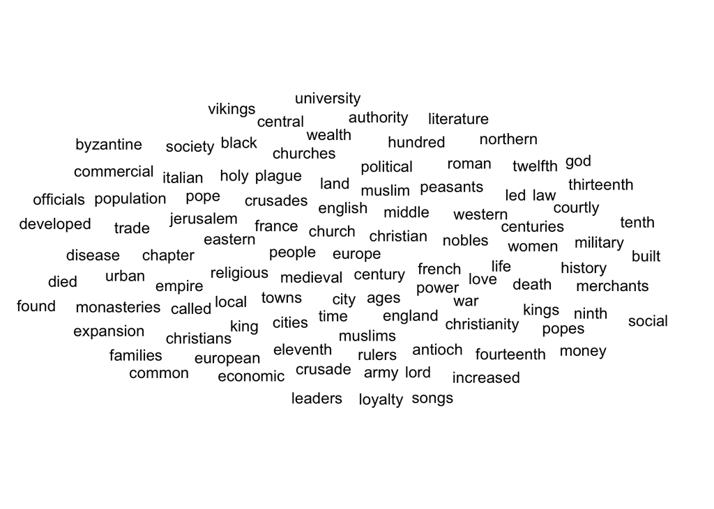

```r
mckay_cloud <- ggplot(data = mckay_top100, aes(label = word)) +
  geom_text_wordcloud() +
  theme_minimal()
mckay_cloud
```

## Customizing the cloud

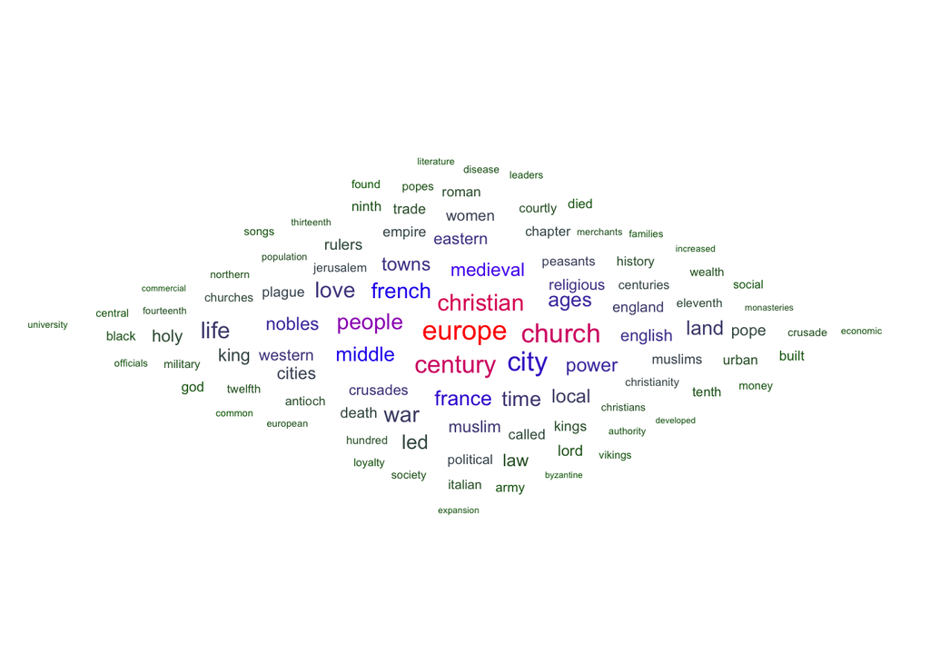

```r
ggplot(data = mckay_top100, aes(label = word, size = n)) +
  geom_text_wordcloud_area(aes(color = n), shape = "diamond") +
  scale_size_area(max_size = 12) +
  scale_color_gradientn(colors = c("darkgreen","blue","red")) +
  theme_minimal()
```

## Sentiment Analysis - aflinn

-The AFINN lexicon assigns words with a score that runs between -5 and 5, with negative scores indicating negative sentiment and positive scores indicating positive sentiment. -“afinn”: Words ranked from -5 (very negative) to +5 (very positive)

First, bind words in `mckay_stop` to `afinn` lexicon:

```r
mckay_afinn <- mckay_stop %>%
  inner_join(get_sentiments("afinn"))
mckay_afinn
```

```
## # A tibble: 751 × 2
##    word      value
##    <chr>     <dbl>
##  1 expand        1
##  2 growing       1
##  3 darkness     -1
##  4 fit           1
##  5 uncertain    -1
##  6 creative      2
##  7 vitality      3
##  8 shared        1
##  9 negative     -2
## 10 restore       1
## # ℹ 741 more rows
```

Let’s find some counts (by sentiment ranking):

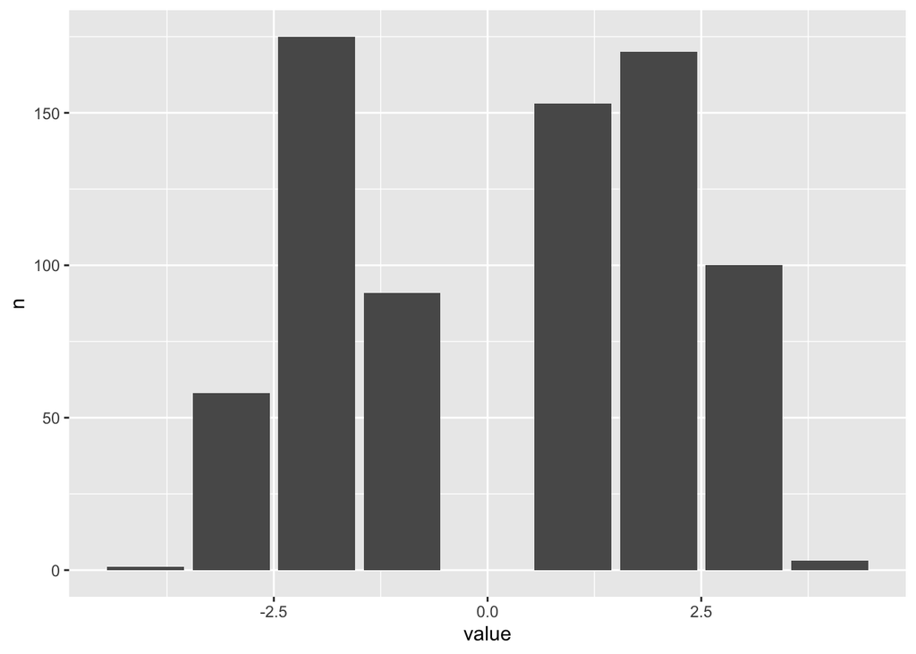

```r
mckay_afinn_hist <- mckay_afinn %>%
  count(value)

# Plot them:
ggplot(data = mckay_afinn_hist, aes(x = value, y = n)) +
  geom_col()
```

Looking closer on some of the negative words (-2)

```r
mckay_afinn2 <- mckay_afinn %>%
  filter(value == -2) %>%
  head(50)
mckay_afinn2
```

```
## # A tibble: 50 × 2
##    word     value
##    <chr>    <dbl>
##  1 negative    -2
##  2 death       -2
##  3 helpless    -2
##  4 disorder    -2
##  5 chaos       -2
##  6 weak        -2
##  7 swearing    -2
##  8 swears      -2
##  9 swears      -2
## 10 swear       -2
## # ℹ 40 more rows
```

```r
# Check the unique 2-score words:
unique(mckay_afinn2$word)
```

```
##  [1] "negative"       "death"          "helpless"       "disorder"
##  [5] "chaos"          "weak"           "swearing"       "swears"
##  [9] "swear"          "defeated"       "war"            "disappointment"
## [13] "debt"           "failures"       "rebellion"      "accused"
## [17] "punished"       "sigh"           "refused"        "lack"
## [21] "restriction"    "threats"        "inquisition"    "fire"
## [25] "illness"        "mourning"       "crushed"        "expel"
## [29] "denied"         "banned"         "enemies"        "conflict"
## [33] "discredited"    "fear"           "choked"         "discord"
## [37] "wicked"         "trickery"       "poor"
```

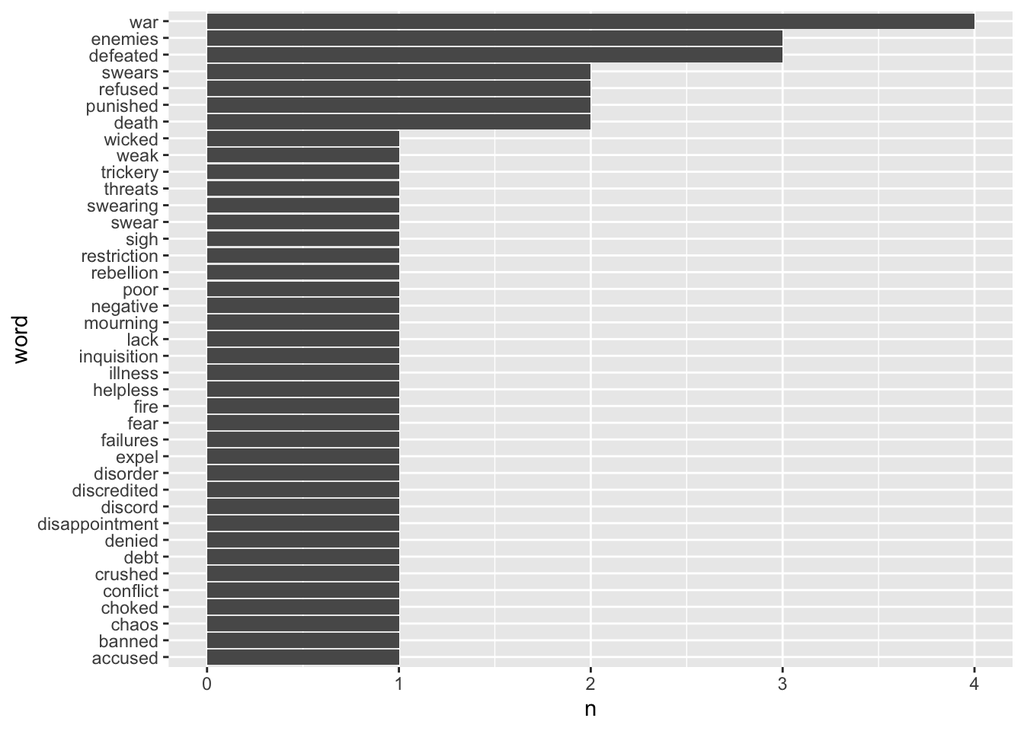

```r
# Count & plot them
mckay_afinn2_n <- mckay_afinn2 %>%
  count(word, sort = TRUE) %>%
  mutate(word = fct_reorder(factor(word), n))


ggplot(data = mckay_afinn2_n, aes(x = word, y = n)) +
  geom_col() +
  coord_flip()
```

```r
mckay_summary <- mckay_afinn %>%
  summarize(
    mean_score = mean(value),
    median_score = median(value)
  )
mckay_summary
```

```
## # A tibble: 1 × 2
##   mean_score median_score
##        <dbl>        <dbl>
## 1      0.248            1
```

-The mean and median indicate *slightly* positive overall sentiments based on the AFINN lexicon.

## Sentiment analysis - nrc

-The nrc lexicon categorizes words in a binary fashion (“yes”/“no”) into categories of positive, negative, anger, anticipation, disgust, fear, joy, sadness, surprise, and trust. -We can use the NRC lexicon to start “binning” text by the feelings they’re typically associated with. As above, we’ll use inner_join() to combine the idig non-stopword text with the nrc lexicon:

```r
mckay_nrc <- mckay_stop %>%
  inner_join(get_sentiments("nrc"))
mckay_nrc
```

```
## # A tibble: 4,277 × 2
##    word       sentiment
##    <chr>      <chr>
##  1 diplomatic positive
##  2 diplomatic trust
##  3 begun      anticipation
##  4 ancient    negative
##  5 time       anticipation
##  6 classical  positive
##  7 darkness   anger
##  8 darkness   fear
##  9 darkness   negative
## 10 darkness   sadness
## # ℹ 4,267 more rows
```

Wait, won’t that exclude some of the words in our text? YES! We should check which are excluded using `anti_join()`:

```r
mckay_exclude <- mckay_stop %>%
  anti_join(get_sentiments("nrc"))

# View(mckay_exclude)

# Count to find the most excluded:
mckay_exclude_n <- mckay_exclude %>%
  count(word, sort = TRUE)

head(mckay_exclude_n)
```

```
## # A tibble: 6 × 2
##   word          n
##   <chr>     <int>
## 1 europe       70
## 2 christian    60
## 3 century      58
## 4 people       48
## 5 medieval     42
## 6 french       38
```

Counts

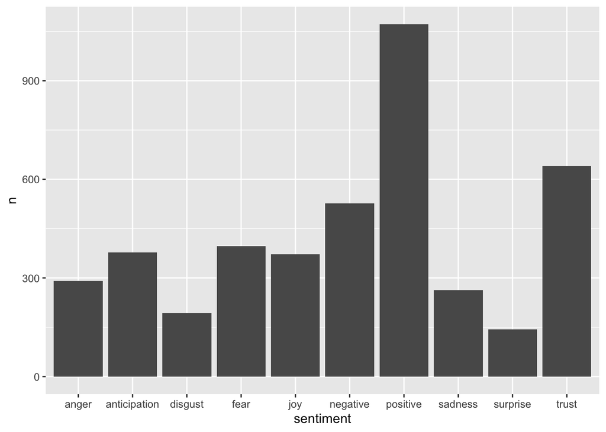

```r
mckay_nrc_n <- mckay_nrc %>%
  count(sentiment, sort = TRUE)

# And plot them:

ggplot(data = mckay_nrc_n, aes(x = sentiment, y = n)) +
  geom_col()
```

Or count by sentiment *and* word, then facet:

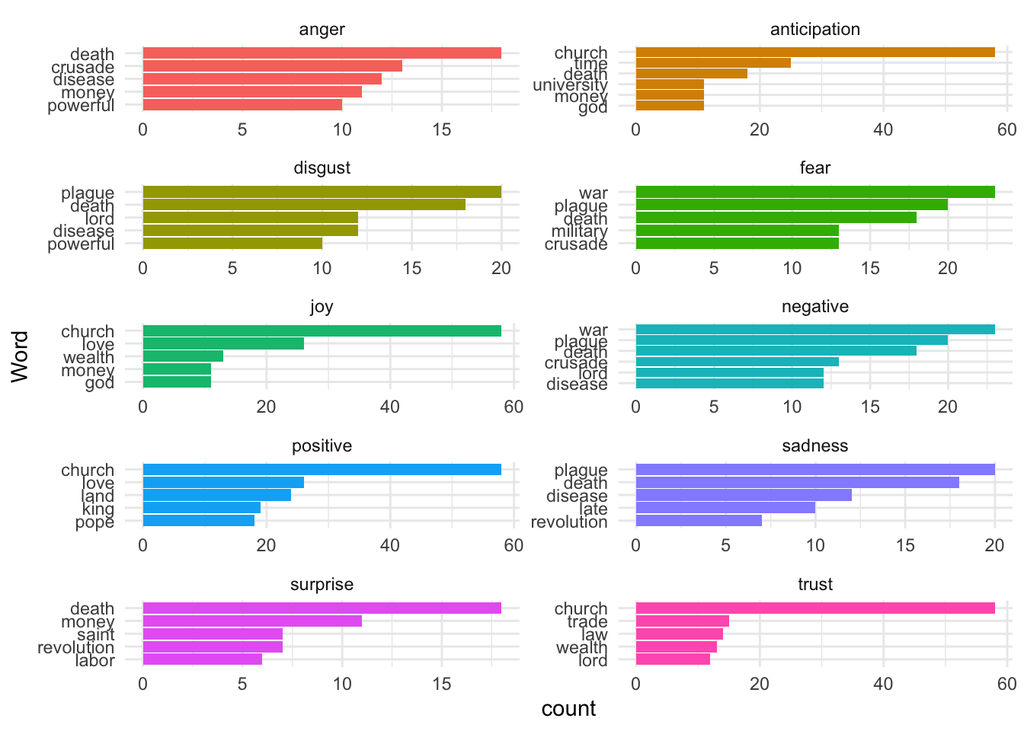

```r
mckay_nrc_n5 <- mckay_nrc %>%
  count(word,sentiment, sort = TRUE) %>%
  group_by(sentiment) %>%
  top_n(5) %>%
  ungroup()

mckay_nrc_gg <- ggplot(data = mckay_nrc_n5, aes(x = reorder(word,n), y = n, fill = sentiment)) +
  geom_col(show.legend = FALSE) +
  facet_wrap(~sentiment, ncol = 2, scales = "free") +
  coord_flip() +
  theme_minimal() +
  labs(x = "Word", y = "count")

# Show it
mckay_nrc_gg
```

## Big picture takeaway

There are serious limitations of sentiment analysis using existing lexicons, and you should **think really hard** about your findings and if a lexicon makes sense for your study. Otherwise, word counts and exploration alone can be useful!

### Credits:

This tutorial is inspired by Allison Horst’s Advanced Statistics and Data Analysis.